# Problem Statement: Predicting Concrete Strength

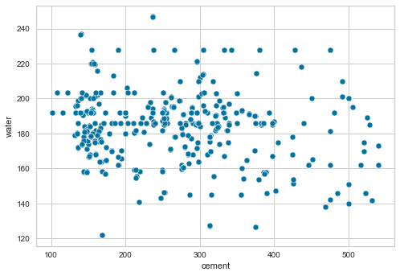

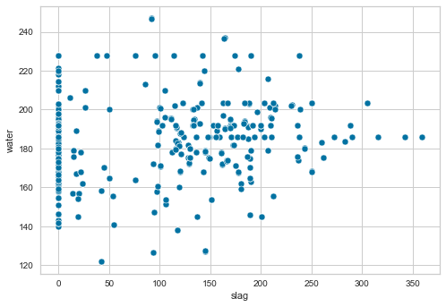

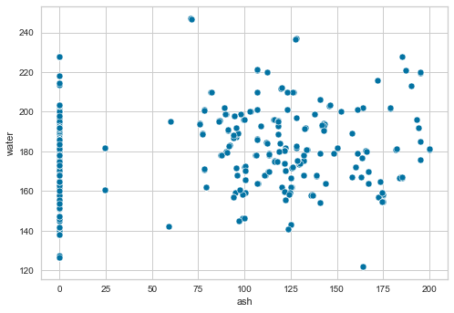

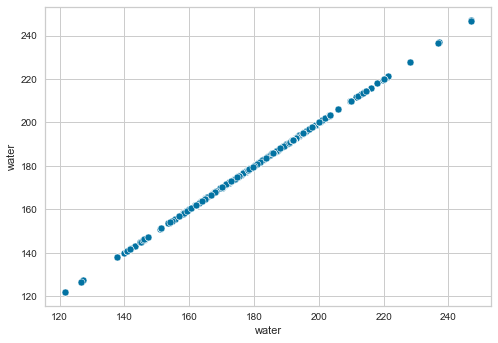

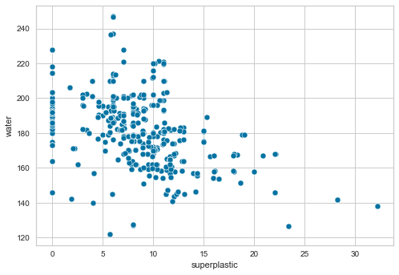

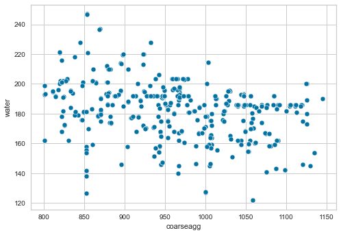

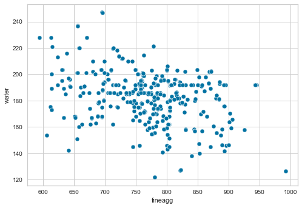

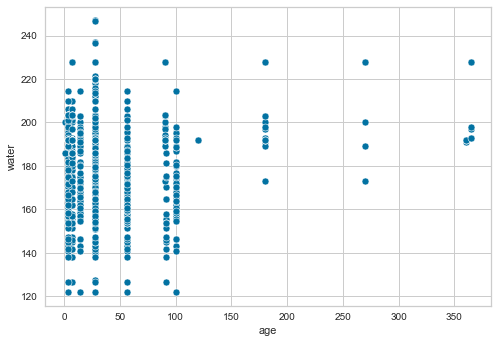

```python
# Checking influence on water
for i in cdata.columns[:-1]:
    sns.scatterplot(x=cdata[i], y=cdata['water'])
    plt.show()
```

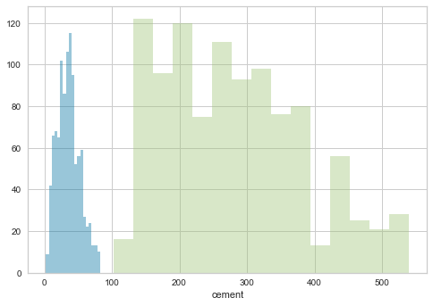

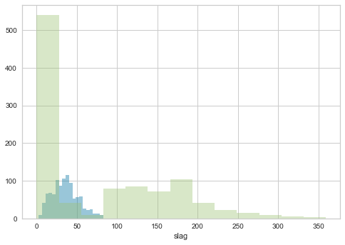

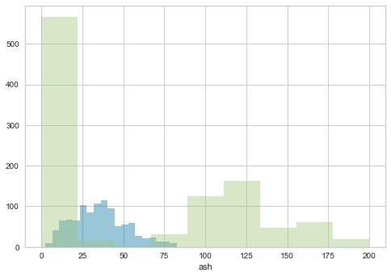

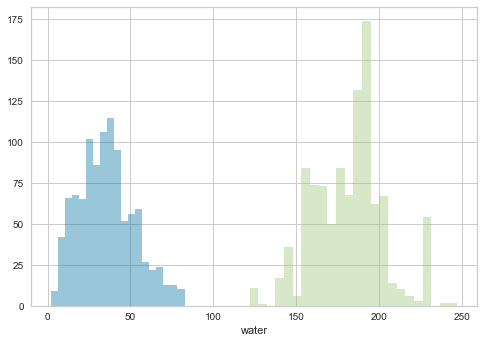

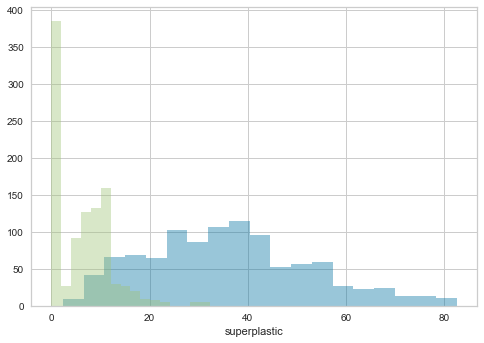

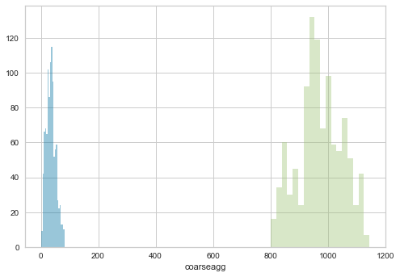

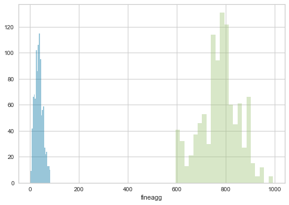

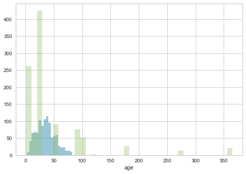

```python
for i in ['cement','slag','ash','water','superplastic','coarseagg','fineagg','age']:
    sns.distplot(cdata['strength'],  kde=False, label='strength')
    sns.distplot(cdata[i],  kde=False,label=i)
    plt.show()
```

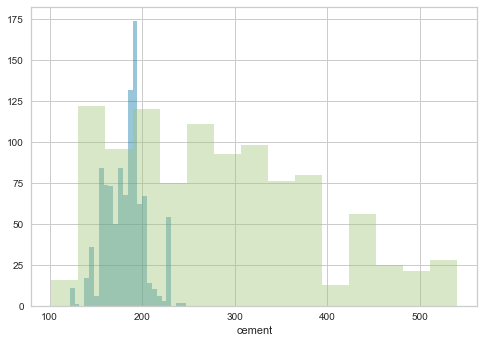

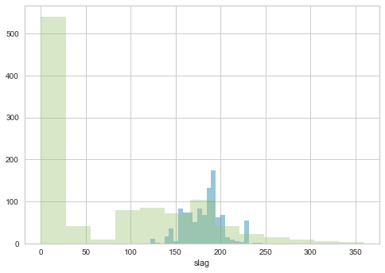

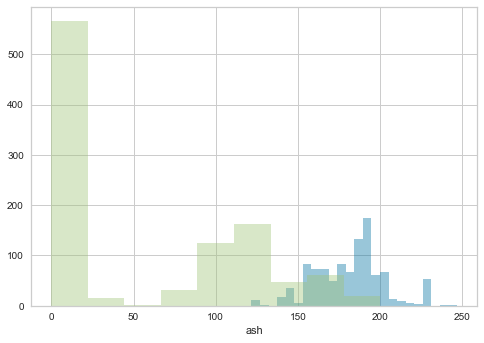

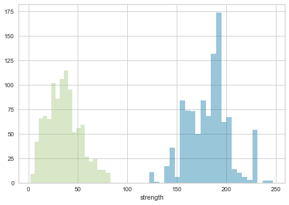

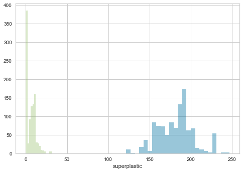

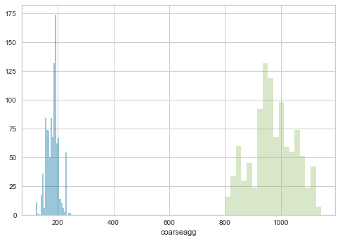

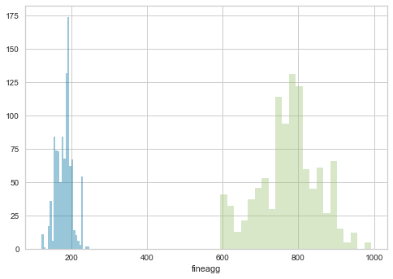

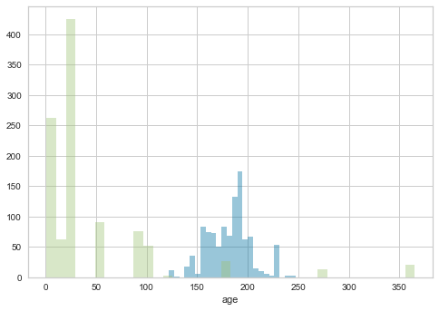

```python
# Water and other variable comparison
for i in ['cement','slag','ash','strength','superplastic','coarseagg','fineagg','age']:
    sns.distplot(cdata['water'],  kde=False, label='water')
    sns.distplot(cdata[i],  kde=False,label=i)
    plt.show()
```

**Insights - Cement & Water**

**Cement - We can observe a high positive correlation between Strength and Cement.**

**This is true because strength of concrete indeed increases with an increase in the amount of cement used in preparing it.**

**Age and Super Plasticizer - are the other two factors influencing Compressive strength.**

**Superplaster - has a strong negative correlation between Super Plasticizer and Water. So whenever adding superplastic the amount of water should be reduced.**

**Ash & fineagg - positive correlations between Superplastic and Fly Ash, Fine Aggregate.**

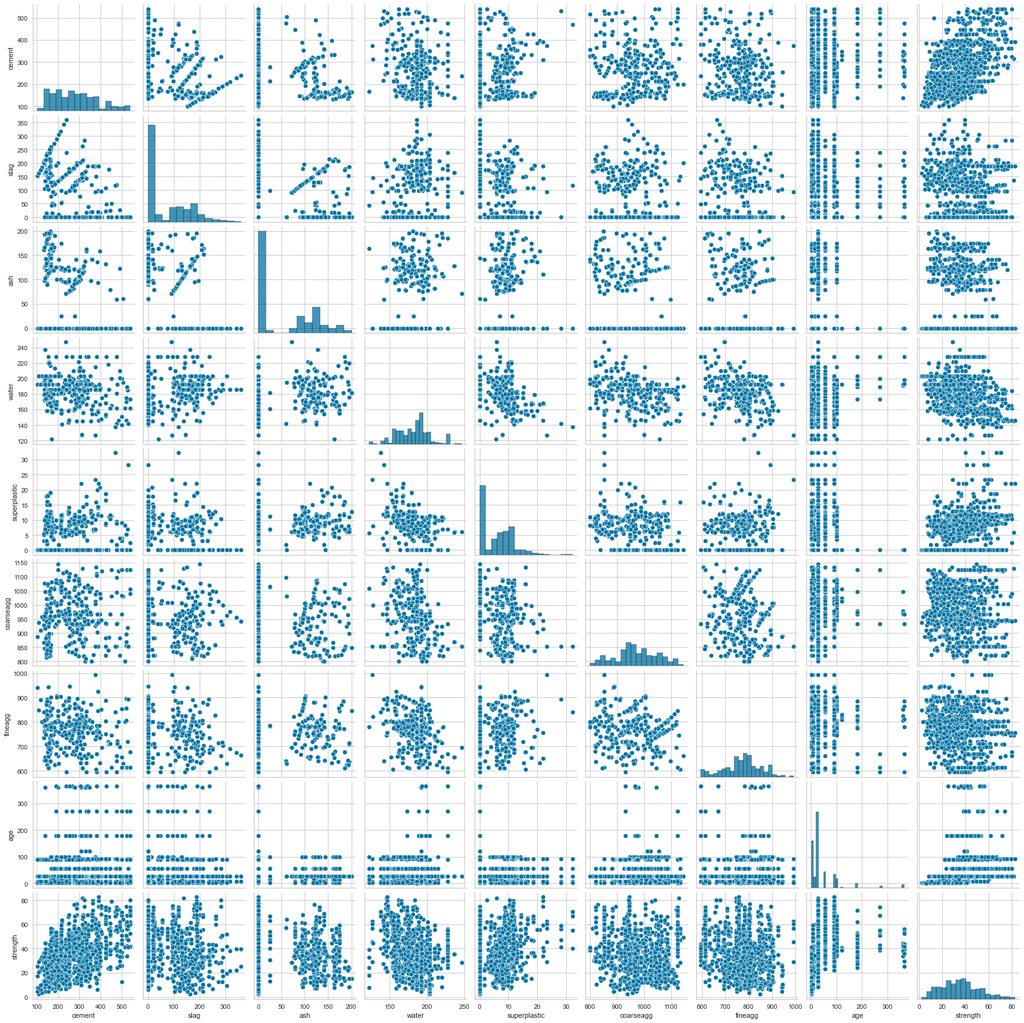

```python
sns.pairplot(data=cdata)
```

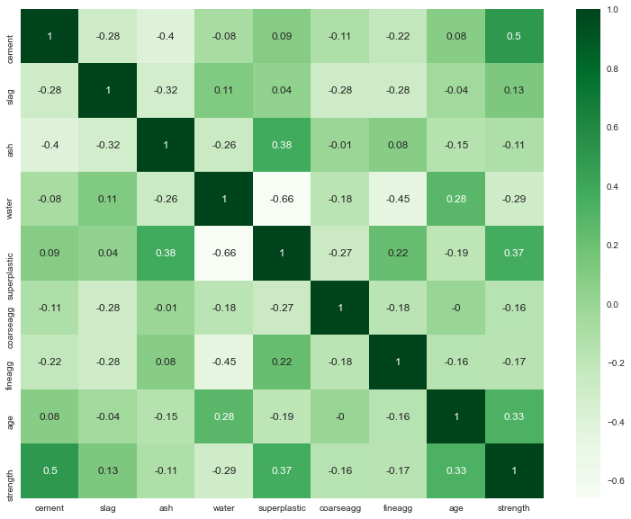

```python
plt.figure (figsize = (13,10))
c = cdata.corr().round(2)
sns.heatmap(c, annot=True,cmap='Greens')
```

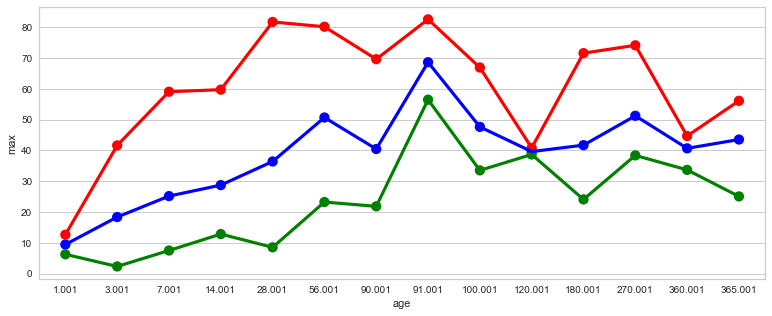

```python
strength_by_age=cdata.groupby("age")["strength"].describe().reset_index()

fig=plt.figure(figsize=(13,5))
sns.pointplot(x="age",y="mean",data=strength_by_age, color="blue")
sns.pointplot(x="age",y="min",data=strength_by_age, color="green")
sns.pointplot(x="age",y="max",data=strength_by_age, color="red")
```

**Insights**

**At the age 120 all min max and mean join togather at one point**

- Cement highlight correlated with strength with 0.49 correlation coefficient
- slag - slightly negativily correlated with ash, superplastic, and fineagg
- ash - correlated with superplastic, cement, slag and water.
- water - highly negatively correlated with superplastic with -0.65 and fineagg 0.44 with age and strenght as well 20%
- superplastic - highly negatively correlated with water -0.65 and 0.34 with strength
- coarseagg - slightly negative correlated with slag andcoarseagg
- fineagg - slightly negative correlated with cement, slag and water
- age - postive correlated with strength and water
- strength - dependent target values positively correlated to cement, superplastic age are most influencing attributes comparing others

# Zero Treatment

```python
#Replace 0 with median
#cdata['slag'].replace(0, cdata['slag'].median(), inplace=True)
#cdata['ash'].replace(0, cdata['ash'].mean(), inplace=True)
#cdata['superplastic'].replace(0, cdata['superplastic'].median(), inplace=True)
```

**Zero mean absense of substance contributed to the strength**

**I dont want to disturbe the model**

**I want to replace the 0 values by small number 0.001 for the multiplication and transformation purpose**

# Data Treatment and Preparation

#### Duplicates Removed

```python
# Remove Duplicates
cdata.drop_duplicates(subset = None,
                     keep = 'first', inplace = True)
```

```python
# add 0.001 for all the values of the data frame

cdata = cdata + 0.001
```

```python
cdata.head()
```

|  | cement | slag | ash | water | superplastic | coarseagg | fineagg | age | strength |
| --- | --- | --- | --- | --- | --- | --- | --- | --- | --- |
| 0 | 141.301 | 212.001 | 0.001 | 203.501 | 0.001 | 971.801 | 748.501 | 28.001 | 29.891 |
| 1 | 168.901 | 42.201 | 124.301 | 158.301 | 10.801 | 1080.801 | 796.201 | 14.001 | 23.511 |
| 2 | 250.001 | 0.001 | 95.701 | 187.401 | 5.501 | 956.901 | 861.201 | 28.001 | 29.221 |
| 3 | 266.001 | 114.001 | 0.001 | 228.001 | 0.001 | 932.001 | 670.001 | 28.001 | 45.851 |
| 4 | 154.801 | 183.401 | 0.001 | 193.301 | 9.101 | 1047.401 | 696.701 | 28.001 | 18.291 |

```python
cdata.describe().T
```

|  | count | mean | std | min | 25% | 50% | 75% | max |
| --- | --- | --- | --- | --- | --- | --- | --- | --- |
| cement | 1005.0 | 278.632343 | 104.344261 | 102.001 | 190.701 | 265.001 | 349.001 | 540.001 |
| slag | 1005.0 | 72.044483 | 86.170807 | 0.001 | 0.001 | 20.001 | 142.501 | 359.401 |
| ash | 1005.0 | 55.537318 | 64.207969 | 0.001 | 0.001 | 0.001 | 118.301 | 200.101 |
| water | 1005.0 | 182.076323 | 21.339334 | 121.801 | 166.601 | 185.701 | 192.901 | 247.001 |
| superplastic | 1005.0 | 6.034234 | 5.919967 | 0.001 | 0.001 | 6.101 | 10.001 | 32.201 |
| coarseagg | 1005.0 | 974.377816 | 77.579667 | 801.001 | 932.001 | 968.001 | 1031.001 | 1145.001 |
| fineagg | 1005.0 | 772.689259 | 80.340435 | 594.001 | 724.301 | 780.001 | 822.201 | 992.601 |
| age | 1005.0 | 45.857716 | 63.734692 | 1.001 | 7.001 | 28.001 | 56.001 | 365.001 |
| strength | 1005.0 | 35.251378 | 16.284815 | 2.331 | 23.521 | 33.801 | 44.871 | 82.601 |

```python
# Converting Age to months
cdata['month'] = cdata['age']/30
cdata['month']=cdata['month'].round(0).astype(int)
cdata['month'].unique()
```

```
array([ 1,  0,  3,  2,  6, 12,  9,  4])
```

```python
# Creating Dummies for Age columns
cdata1 = pd.get_dummies(cdata['month']).rename(columns=lambda x: 'month' + str(x))
cdata = pd.concat([cdata, cdata1], axis=1)
cdata.head()
```

|  | cement | slag | ash | water | superplastic | coarseagg | fineagg | age | strength | month | month0 | month1 | month2 | month3 | month4 | month6 | month9 | month12 |
| --- | --- | --- | --- | --- | --- | --- | --- | --- | --- | --- | --- | --- | --- | --- | --- | --- | --- | --- |
| 0 | 141.301 | 212.001 | 0.001 | 203.501 | 0.001 | 971.801 | 748.501 | 28.001 | 29.891 | 1 | 0 | 1 | 0 | 0 | 0 | 0 | 0 | 0 |
| 1 | 168.901 | 42.201 | 124.301 | 158.301 | 10.801 | 1080.801 | 796.201 | 14.001 | 23.511 | 0 | 1 | 0 | 0 | 0 | 0 | 0 | 0 | 0 |
| 2 | 250.001 | 0.001 | 95.701 | 187.401 | 5.501 | 956.901 | 861.201 | 28.001 | 29.221 | 1 | 0 | 1 | 0 | 0 | 0 | 0 | 0 | 0 |
| 3 | 266.001 | 114.001 | 0.001 | 228.001 | 0.001 | 932.001 | 670.001 | 28.001 | 45.851 | 1 | 0 | 1 | 0 | 0 | 0 | 0 | 0 | 0 |
| 4 | 154.801 | 183.401 | 0.001 | 193.301 | 9.101 | 1047.401 | 696.701 | 28.001 | 18.291 | 1 | 0 | 1 | 0 | 0 | 0 | 0 | 0 | 0 |

```python
# ADDING NEW FEATURES
# Predominantly concret is full of cement so creating new features by mulitply the features with cement

cdata['cement_slag'] = (cdata['cement']*cdata['slag'])/(cdata['cement']+cdata['slag'])
cdata['cement_ash'] = (cdata['cement']*cdata['ash'])/(cdata['cement']+cdata['ash'])
cdata['cement_superplastic'] = (cdata['cement']*cdata['superplastic'])/(cdata['cement']+cdata['superplastic'])
cdata['cement_coarseagg'] = (cdata['cement']*cdata['coarseagg'])/(cdata['cement']+cdata['coarseagg'])
cdata['cement_fineagg'] = (cdata['cement']*cdata['fineagg'])/(cdata['cement']+cdata['fineagg'])
```

```python
cdata.describe().T
```

|  | count | mean | std | min | 25% | 50% | 75% | max |
| --- | --- | --- | --- | --- | --- | --- | --- | --- |
| cement | 1005.0 | 278.632343 | 104.344261 | 102.001000 | 190.701000 | 265.001000 | 349.001000 | 540.001000 |
| slag | 1005.0 | 72.044483 | 86.170807 | 0.001000 | 0.001000 | 20.001000 | 142.501000 | 359.401000 |
| ash | 1005.0 | 55.537318 | 64.207969 | 0.001000 | 0.001000 | 0.001000 | 118.301000 | 200.101000 |
| water | 1005.0 | 182.076323 | 21.339334 | 121.801000 | 166.601000 | 185.701000 | 192.901000 | 247.001000 |
| superplastic | 1005.0 | 6.034234 | 5.919967 | 0.001000 | 0.001000 | 6.101000 | 10.001000 | 32.201000 |
| coarseagg | 1005.0 | 974.377816 | 77.579667 | 801.001000 | 932.001000 | 968.001000 | 1031.001000 | 1145.001000 |
| fineagg | 1005.0 | 772.689259 | 80.340435 | 594.001000 | 724.301000 | 780.001000 | 822.201000 | 992.601000 |
| age | 1005.0 | 45.857716 | 63.734692 | 1.001000 | 7.001000 | 28.001000 | 56.001000 | 365.001000 |
| strength | 1005.0 | 35.251378 | 16.284815 | 2.331000 | 23.521000 | 33.801000 | 44.871000 | 82.601000 |
| cement_slag | 1005.0 | 41.192925 | 45.291285 | 0.001000 | 0.001000 | 19.018106 | 80.526374 | 150.935968 |
| cement_ash | 1005.0 | 34.893988 | 38.933985 | 0.001000 | 0.001000 | 0.001000 | 75.517352 | 113.020413 |
| cement_superplastic | 1005.0 | 5.779094 | 5.613799 | 0.001000 | 0.001000 | 5.889853 | 9.630558 | 30.132165 |
| cement_coarseagg | 1005.0 | 211.112231 | 60.923276 | 91.481098 | 161.973079 | 205.762006 | 257.380606 | 364.865427 |
| cement_fineagg | 1005.0 | 198.130619 | 52.872075 | 92.035306 | 153.815868 | 196.526284 | 236.392542 | 333.209522 |

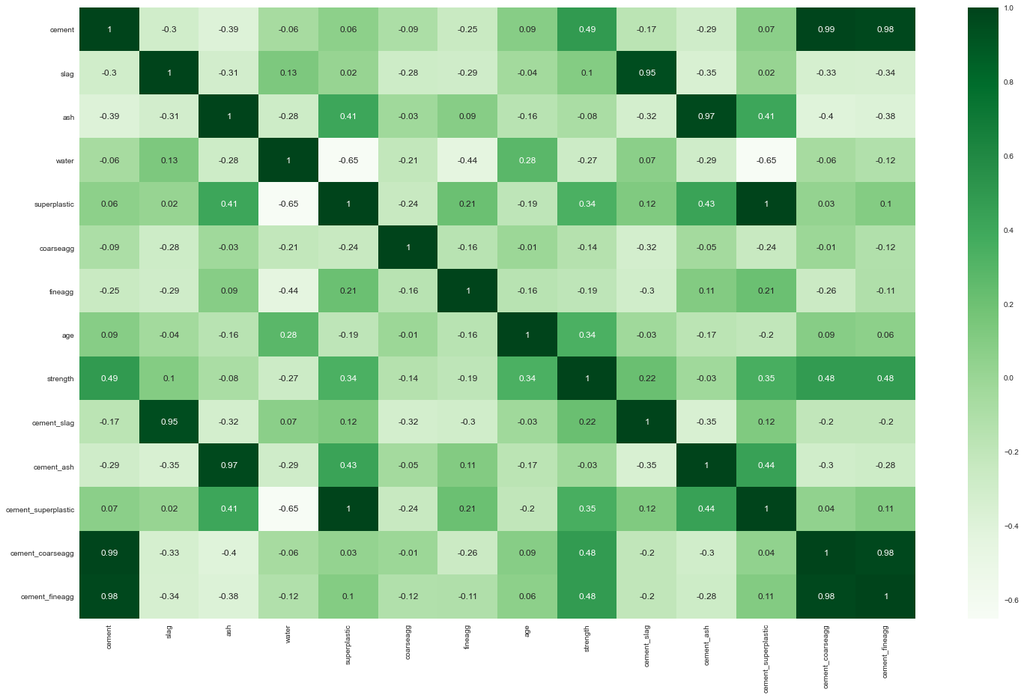

```python
plt.figure (figsize = (25,15))
new = cdata.corr().round(2)
sns.heatmap(new, annot=True,cmap='Greens')
```

**Insights**

```python
# FEATURE INCLUENTIAL TARGET VARIABLES
new1 = cdata.corr().sort_values('strength', ascending=False).index
new1
```

```
Index(['strength', 'cement', 'cement_fineagg', 'cement_coarseagg',
       'cement_superplastic', 'superplastic', 'age', 'cement_slag', 'slag',
       'cement_ash', 'ash', 'coarseagg', 'fineagg', 'water'],
      dtype='object')
```

## Spliting the Train and Test

```python
#X = cdata.drop(['strength','age','month', 'month4', 'month12'], axis=1)
X = cdata.drop(['strength'], axis=1)
X.head()
y = cdata['strength']
X.head()
```

[output not shown]

```python
# Splitting the data into train and test

X_train, X_test, y_train, y_test = train_test_split(X , y, test_size=0.3, random_state=7)
```

```python
#Degree 1
from sklearn.pipeline import Pipeline
from sklearn.preprocessing import StandardScaler
from sklearn.tree import DecisionTreeRegressor

pipeline=Pipeline([('scalar',StandardScaler()),
                   ('reg',DecisionTreeRegressor(random_state=7))])


pipeline.fit(X_train, y_train)

print(pipeline.score(X_train, y_train))

print(pipeline.score(X_test, y_test))
```

```
0.9961253299308925
0.8057624298912767
```

```python
#Degree 2
from sklearn.pipeline import Pipeline
from sklearn.preprocessing import PolynomialFeatures

pipeline = Pipeline([
    ('scaler',StandardScaler()),
    ('poly',PolynomialFeatures(degree=2, interaction_only=True)),
    ('reg', DecisionTreeRegressor(random_state=7))
])

pipeline.fit(X_train, y_train)

print(pipeline.score(X_train, y_train))

print(pipeline.score(X_test, y_test))
```

```
0.9961253299308925
0.7853406098152871
```

```python
#Degree 3

pipeline = Pipeline([
    ('scaler',StandardScaler()),
    ('poly', PolynomialFeatures(degree=3, interaction_only=True)),
    ('reg', DecisionTreeRegressor(random_state=7))
])

pipeline.fit(X_train, y_train)

print(pipeline.score(X_train, y_train))

print(pipeline.score(X_test, y_test))
```

```
0.9961253299308925
0.7634205290296665
```

### Insights:

- As it is visible that highest testing score is in degree one so going fprward with degree 1

# Model:

1. Different Models:

```python
from sklearn.model_selection import cross_val_score, KFold
k = KFold(random_state=7, n_splits=5, shuffle=True)

# KFold will split the data in 5 equal parts
```

```python
algo= []
cv_r2_mean = []
cv_r2_std = []
cv_rmse_mean = []

# Blanks list to store model name, cross validated r2 score (mean and standard deviation) and RMSE
```

```python
# Linear Regression
## Since the dataset is small theefore using compete dataset for cv
from sklearn.linear_model import LinearRegression
from sklearn.preprocessing import StandardScaler
pipeline = Pipeline([
    ('scaler', StandardScaler()),
    ('reg', LinearRegression())
])

pipeline.fit(X_train, y_train)


algo.append('Linear Regression')
cv_r2_mean.append(cross_val_score(pipeline, X, y, cv=k).mean())
cv_r2_std.append(cross_val_score(pipeline, X, y, cv=k).std())
cv_rmse_mean.append((-cross_val_score(pipeline, X, y, cv=k, scoring='neg_mean_squared_error').mean())**0.5)
```

### Note: When we use mean squared error as scoring in cross val score it gives output with a negative sign. So we use Negative sign to make it positive.

```python
# Decision Tree

model = DecisionTreeRegressor(random_state=7)

model.fit(X_train, y_train)


algo.append('Decision Tree')
cv_r2_mean.append(cross_val_score(model,X, y, cv=k).mean())
cv_r2_std.append(cross_val_score(model, X, y, cv=k).std())
cv_rmse_mean.append((-cross_val_score(model, X, y, cv=k, scoring='neg_mean_squared_error').mean())**0.5)
```

```python
dt_model=DecisionTreeRegressor()
dt_model.fit(X_train,y_train)

print(dt_model.score(X_train,y_train))
print(dt_model.score(X_test,y_test))
print(pd.DataFrame(dt_model.feature_importances_,columns=["Imp"],index=X_train.columns))
```

```
0.9961253299308925
0.8109130516633742
                          Imp
cement               0.225005
slag                 0.015828
ash                  0.012569
water                0.112585
superplastic         0.080255
coarseagg            0.024156
fineagg              0.029839
age                  0.340333
cement_slag          0.071240
cement_ash           0.004249
cement_superplastic  0.031176
cement_coarseagg     0.042706
cement_fineagg       0.010059
```

```python
#Lasso
from sklearn.linear_model import Lasso
pipeline = Pipeline([
    ('scaler', StandardScaler()),
    ('reg', Lasso())
])

pipeline.fit(X_train, y_train)


algo.append('Lasso')
cv_r2_mean.append(cross_val_score(pipeline, X, y, cv=k).mean())
cv_r2_std.append(cross_val_score(pipeline, X, y, cv=k).std())
cv_rmse_mean.append((-cross_val_score(pipeline, X, y, cv=k, scoring='neg_mean_squared_error').mean())**0.5)
```

```python
lasso_model=Lasso()
lasso_model.fit(X_train,y_train)

print(lasso_model.score(X_train,y_train))
print(lasso_model.score(X_test,y_test))
print(pd.DataFrame(lasso_model.coef_,columns=["Imp"],index=X_train.columns))
```

```
0.5975702417339428
0.6563457558845065
                          Imp
cement               0.050513
slag                 0.042845
ash                 -0.000000
water               -0.174168
superplastic         0.000000
coarseagg            0.004271
fineagg              0.007659
age                  0.108135
cement_slag          0.097170
cement_ash           0.117734
cement_superplastic  0.203920
cement_coarseagg     0.082260
cement_fineagg      -0.000000
```

```python
# Random Forest
from sklearn.ensemble import RandomForestRegressor

model = RandomForestRegressor(random_state=7)

model.fit(X_train, y_train)


algo.append('Random Forest')
cv_r2_mean.append(cross_val_score(model, X, y, cv=k).mean())
cv_r2_std.append(cross_val_score(model, X, y, cv=k).std())
cv_rmse_mean.append((-cross_val_score(model, X, y, cv=k, scoring='neg_mean_squared_error').mean())**0.5)
```

```python
# Bagging
from sklearn.ensemble import BaggingRegressor

model = BaggingRegressor(random_state=7)

model.fit(X_train, y_train)


algo.append('Bagging')
cv_r2_mean.append(cross_val_score(model, X, y, cv=k).mean())
cv_r2_std.append(cross_val_score(model, X, y, cv=k).std())
cv_rmse_mean.append((-cross_val_score(model, X, y, cv=k, scoring='neg_mean_squared_error').mean())**0.5)
```

```python
# AdaBoost
from sklearn.ensemble import AdaBoostRegressor

model = AdaBoostRegressor(random_state=7)

model.fit(X_train, y_train)


algo.append('AdaBoost')
cv_r2_mean.append(cross_val_score(model, X, y, cv=k).mean())
cv_r2_std.append(cross_val_score(model, X, y, cv=k).std())
cv_rmse_mean.append((-cross_val_score(model, X, y, cv=k, scoring='neg_mean_squared_error').mean())**0.5)
```

```python
# Gradient Boosting
from sklearn.ensemble import GradientBoostingRegressor

model = GradientBoostingRegressor(random_state=7)

model.fit(X_train, y_train)

algo.append('Gradient Boosting')
cv_r2_mean.append(cross_val_score(model, X, y, cv=k).mean())
cv_r2_std.append(cross_val_score(model, X, y, cv=k).std())
cv_rmse_mean.append((-cross_val_score(model, X, y, cv=k, scoring='neg_mean_squared_error').mean())**0.5)
```

```python
# DataFrame to compare results.

results = pd.DataFrame()
results['Model'] = algo
results['CV R2 score mean'] = cv_r2_mean
results['CV R2 score std'] = cv_r2_std
results['CV RMSE'] = cv_rmse_mean
results = results.set_index('Model')
results
```

| Model | CV R2 score mean | CV R2 score std | CV RMSE |
| --- | --- | --- | --- |
| Linear Regression | 0.611046 | 0.062489 | 10.117974 |
| Decision Tree | 0.849632 | 0.033096 | 6.333945 |
| Lasso | 0.567373 | 0.030755 | 10.690540 |
| Random Forest | 0.903944 | 0.022277 | 5.056779 |
| Bagging | 0.888896 | 0.024065 | 5.437632 |
| AdaBoost | 0.785797 | 0.013137 | 7.526856 |
| Gradient Boosting | 0.903617 | 0.020526 | 5.063658 |

### Hyper Parameter Tuning

```python
from sklearn.model_selection import GridSearchCV

rf = RandomForestRegressor(random_state=7)

params = {
    'bootstrap': [True, False],
    'max_depth': [3, 4, None],
    'max_features': ['sqrt', 'log2'],
    'min_samples_leaf': [1, 3, 4],
    'min_samples_split': [2, 3, 5],
    'n_estimators': [4, 25, 50]
}

grid = GridSearchCV(estimator=rf, param_grid=params, cv=k)

grid.fit(X_train, y_train)
```

```
GridSearchCV(cv=KFold(n_splits=5, random_state=7, shuffle=True),
             estimator=RandomForestRegressor(random_state=7),
             param_grid={'bootstrap': [True, False], 'max_depth': [3, 4, None],
                         'max_features': ['sqrt', 'log2'],
                         'min_samples_leaf': [1, 3, 4],
                         'min_samples_split': [2, 3, 5],
                         'n_estimators': [4, 25, 50]})
```

```python
from sklearn.metrics import mean_squared_error
model = ['Random forest after Grid search']
tr = [grid.score(X_train, y_train)]
te = [grid.score(X_test, y_test)]
rmse = [mean_squared_error(y_test, grid.predict(X_test))**0.5]
```

### Random Search on Gradient Boosting

```python
gb = GradientBoostingRegressor(random_state=7)
gb.fit(X_train, y_train)
```

```
GradientBoostingRegressor(random_state=7)
```

```python
from sklearn.model_selection import RandomizedSearchCV

# Number of trees in random forest
n_estimators = [int(x) for x in np.linspace(start=50, stop=150, num=25)]   # returns evenly spaced 25 numbers
# Number of features to consider at every split
max_features = ['log2', 'sqrt']
# Maximum number of levels in tree
max_depth = [int(x) for x in np.linspace(5, 10, num=5)]  # returns evenly spaced numbers can be changed to any
max_depth.append(None)
# Minimum number of samples required to split a node
min_samples_split = [2, 3, 4, 5, 6, 7, 8, 9, 10]
# Minimum number of samples required at each leaf node
min_samples_leaf = [1, 2, 3, 4]
# Method of selecting samples for training each tree
learning_rate = [float(x) for x in np.linspace(0.1, 1, num=10)]

# Create the random grid
params_r = {'n_estimators': n_estimators,
            'max_features': max_features,
            'max_depth': max_depth,
            'min_samples_split': min_samples_split,
            'min_samples_leaf': min_samples_leaf,
            'learning_rate': learning_rate}

# Use the random grid to search for best hyperparameters

# Random search of parameters, using 3 fold cross validation,
# search across 100 different combinations, and use all available cores
random = RandomizedSearchCV(estimator=gb, param_distributions=params_r, cv=k, random_state=7)

# Fit the random search model
random.fit(X_train, y_train)
```

```
RandomizedSearchCV(cv=KFold(n_splits=5, random_state=7, shuffle=True),
                   estimator=GradientBoostingRegressor(random_state=7),
                   param_distributions={'learning_rate': [0.1, 0.2,
                                                          0.30000000000000004,
                                                          0.4, 0.5, 0.6,
                                                          0.7000000000000001,
                                                          0.8, 0.9, 1.0],
                                        'max_depth': [5, 6, 7, 8, 10, None],
                                        'max_features': ['log2', 'sqrt'],
                                        'min_samples_leaf': [1, 2, 3, 4],
                                        'min_samples_split': [2, 3, 4, 5, 6, 7,
                                                              8, 9, 10],
                                        'n_estimators': [50, 54, 58, 62, 66, 70,
                                                         75, 79, 83, 87, 91, 95,
                                                         100, 104, 108, 112,
                                                         116, 120, 125, 129,
                                                         133, 137, 141, 145,
                                                         150]},
                   random_state=7)
```

```python
random.best_params_
```

```
{'n_estimators': 120,
 'min_samples_split': 8,
 'min_samples_leaf': 4,
 'max_features': 'sqrt',
 'max_depth': None,
 'learning_rate': 0.1}
```

```python
model.append('Gradient Boosting after RandomCV')
tr.append(random.score(X_train, y_train))
te.append(random.score(X_test, y_test))
rmse.append(mean_squared_error(y_test, random.predict(X_test))**0.5)
```

```python
# DataFrame to compare results.

results = pd.DataFrame()
results['Model'] = model
results['Training Score'] = tr
results['Testing Score'] = te
results['RMSE'] = rmse
results = results.set_index('Model')
results
```

| Model | Training Score | Testing Score | RMSE |
| --- | --- | --- | --- |
| Random forest after Grid search | 0.968577 | 0.888993 | 5.366103 |
| Gradient Boosting after RandomCV | 0.995035 | 0.939400 | 3.964799 |

Our final model is slightly overfit but the testing score is high enough so we can use this model for now or we can try to reduce noise by changing parameters

```python
concrete_XY=X.join(y)
```

```python
values=concrete_XY.values
```

```python
from sklearn.utils import resample
n_iterations=1000
n_size=int(len(cdata)*1)

stats=list()
for i in range(n_iterations):
    train=resample(values,n_samples=n_size)
    test=np.array([x for x in values if x.tolist() not in train.tolist()])

    gb=random.best_estimator_
    gb.fit(train[:,:-1],train[:,-1])
    y_test2=test[:,-1]

    predictions=gb.predict(test[:,:-1])
    score=gb.score(test[:,:-1],y_test2)

    stats.append(score)
```

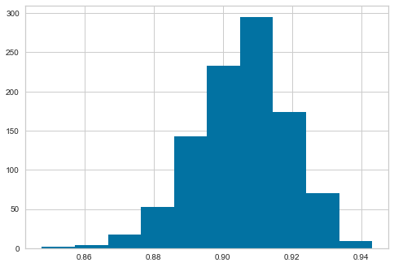

```
At 95.0 % confidence interval the model accuracy will be between 87.77 and 87.97
```

```python
plt.hist(stats)
plt.show()
alpha=0.95
p=((1-alpha)/2)*100
lower=max(0.0,np.percentile(stats,p))
p=(alpha+((1.0-alpha)/2*100))
upper=min(1.0,np.percentile(stats,p))
#print('%.1f, confidence interval %.1f%% and %.1f%%', (alpha*100,lower*100, upper*100)
print("At",(alpha*100),"% confidence interval the model accuracy will be between",(lower*100).round(2),"and", (upper*100).round(2))
```